# R Notebook

# Introduction

This notebook intends to exemplify the workflow for a Churn project that contains not only the predictive part of the churn, but also an study about the applicable treatments and their effects on the target variable. The project structure is shown in the README.md file of the git, so it’s a good ideia to go and read that to have a better understanding of the hole process.

The data that we are going to use is the ‘Telecomunication Costumer Churn’, so it is about the costumers that leave the company for any given reason. For that we have a csv file that contains 7032 rows and 21 columns, one of them being the Churn column.

# ETL

The first step for any project is the ETL so we can clean and do some feature enginnering to ease our task later. This step is iterative and may be revisited and better explained as the project goes by.

Here I have filter the ‘tenure’ column to remove the zero values since this column gives us the time that the client is with the company as months and we don’t learn much from the clients that just joined the company. When working with the semi-parametric Cox proportional hazard model it was seen that the automatic payment methods had no significant difference, so we combine them to reduce our estimated parameters.

```r
data <-
  read_csv('Telco_Costumer_Churn.csv')%>%
  filter(tenure != 0) %>%
  mutate(PaymentMethod = ifelse(stringr::str_detect(PaymentMethod, 'automatic'), 'Automatic', PaymentMethod),
         SeniorCitizen = factor(SeniorCitizen, levels = c(0, 1), labels = c('No', 'Yes')),
         Churn = ifelse(Churn == 'Yes', 1 ,0))  %>%
  mutate_if(is.character, as.factor)

# Define variables
time <- data$tenure
event <- data$Churn
X <- data %>% select(-contains('ID'), -Churn, -tenure)
```

# Exploratory Data Analysis

As we can see from the table below there is a little rigth skewness on the data, since the median is lower than the mean, and, although its not a proof, that indicates non-normality on the data, a characteristic that we already waited, since we are going to try and model it with survival models. The oldest client of the company is there for 6 years at total, while the average would be around 2 years and a half.

```r
summary(time)
```

```
##    Min. 1st Qu.  Median    Mean 3rd Qu.    Max.
##    1.00    9.00   29.00   32.42   55.00   72.00
```

The histogram reinforces our view that the data is both non normal and right skewed, as expected on this kind of problem, since most people either change companies really quickly or keep their lines for a long time.

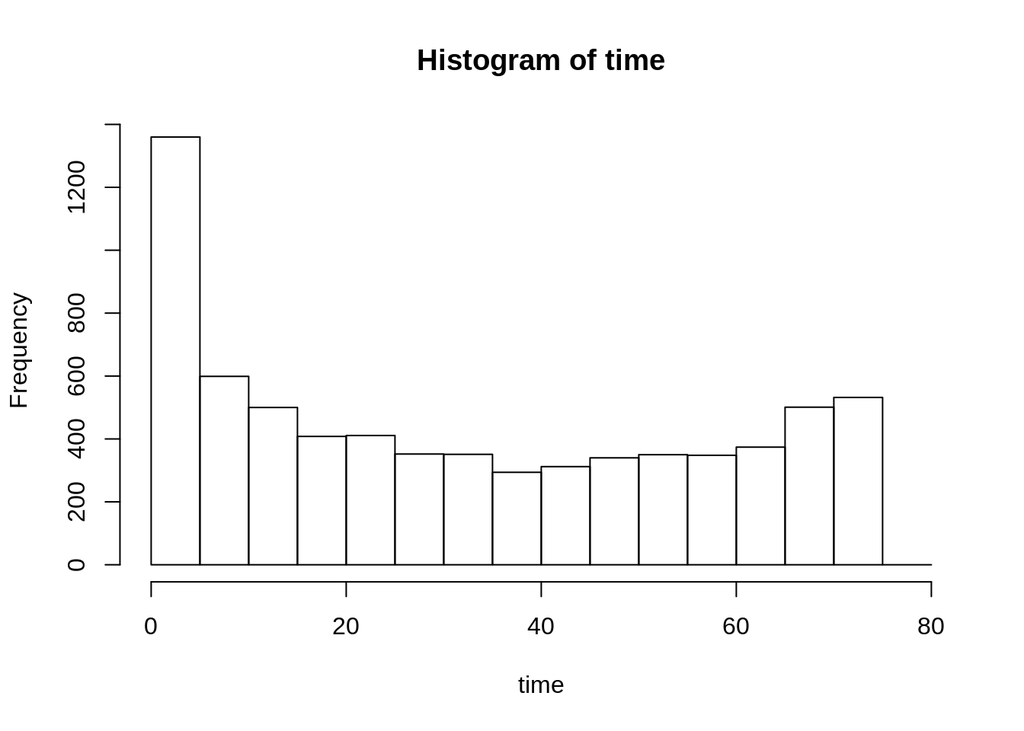

```r
hist(time, breaks = seq(0, 80, 5))
```

This telcom has a total of 27% of churn, as we can see in the table below.

```r
table(event) %>% prop.table() %>% round(2)
```

```
## event
##    0    1
## 0.73 0.27
```

```r
summary(X)
```

```
##     gender     SeniorCitizen Partner    Dependents PhoneService
##  Female:3483   No :5890      No :3639   No :4933   No : 680
##  Male  :3549   Yes:1142      Yes:3393   Yes:2099   Yes:6352
##
##
##
##
##           MultipleLines     InternetService             OnlineSecurity
##  No              :3385   DSL        :2416   No                 :3497
##  No phone service: 680   Fiber optic:3096   No internet service:1520
##  Yes             :2967   No         :1520   Yes                :2015
##
##
##
##               OnlineBackup             DeviceProtection
##  No                 :3087   No                 :3094
##  No internet service:1520   No internet service:1520
##  Yes                :2425   Yes                :2418
##
##
##
##               TechSupport                StreamingTV
##  No                 :3472   No                 :2809
##  No internet service:1520   No internet service:1520
##  Yes                :2040   Yes                :2703
##
##
##
##             StreamingMovies           Contract    PaperlessBilling
##  No                 :2781   Month-to-month:3875   No :2864
##  No internet service:1520   One year      :1472   Yes:4168
##  Yes                :2731   Two year      :1685
##
##
##
##           PaymentMethod  MonthlyCharges    TotalCharges
##  Automatic       :3063   Min.   : 18.25   Min.   :  18.8
##  Electronic check:2365   1st Qu.: 35.59   1st Qu.: 401.4
##  Mailed check    :1604   Median : 70.35   Median :1397.5
##                          Mean   : 64.80   Mean   :2283.3
##                          3rd Qu.: 89.86   3rd Qu.:3794.7
##                          Max.   :118.75   Max.   :8684.8
```

# Modelling

```r
logistic <-  survreg(Surv(time,event) ~ .,
                        data = select(X, -MultipleLines, -OnlineBackup, -OnlineSecurity,
                                      -DeviceProtection, -TechSupport, -StreamingTV,
                                      -StreamingMovies, -gender, -SeniorCitizen),
                        dist="logistic")
summary(logistic)
```

```
##
## Call:
## survreg(formula = Surv(time, event) ~ ., data = select(X, -MultipleLines,
##     -OnlineBackup, -OnlineSecurity, -DeviceProtection, -TechSupport,
##     -StreamingTV, -StreamingMovies, -gender, -SeniorCitizen),
##     dist = "logistic")
##                                   Value Std. Error      z       p
## (Intercept)                   29.879801   0.944740  31.63 < 2e-16
## PartnerYes                     1.364538   0.361308   3.78 0.00016
## DependentsYes                  0.993628   0.435676   2.28 0.02257
## PhoneServiceYes               -0.987485   0.750015  -1.32 0.18797
## InternetServiceFiber optic    -1.999276   0.633147  -3.16 0.00159
## InternetServiceNo              9.298263   1.088320   8.54 < 2e-16
## ContractOne year               9.789815   0.611966  16.00 < 2e-16
## ContractTwo year              27.205313   1.109378  24.52 < 2e-16
## PaperlessBillingYes           -1.015998   0.366469  -2.77 0.00556
## PaymentMethodElectronic check -2.682138   0.378048  -7.09 1.3e-12
## PaymentMethodMailed check     -3.902111   0.490173  -7.96 1.7e-15
## MonthlyCharges                -0.276040   0.017377 -15.89 < 2e-16
## TotalCharges                   0.012023   0.000132  91.34 < 2e-16
## Log(scale)                     1.631245   0.019456  83.84 < 2e-16
##
## Scale= 5.11
##
## Logistic distribution
## Loglik(model)= -8242.5   Loglik(intercept only)= -12122
##  Chisq= 7758.97 on 12 degrees of freedom, p= 0
## Number of Newton-Raphson Iterations: 11
## n= 7032
```

The root mean squared error of the model was almost 20, so it is probabily a good fit.

```r
se(time, predict(logistic, type ='response')) %>% mean %>% sqrt
```

```
## [1] 19.79915
```

We can see the MAPE as well, and here we have that the median absolute percentual error is .40, or 40%, which is, for our case, an acceptable error.

```r
pe(time, predict(logistic, type ='response')) %>% abs %>% median
```

```
## [1] 0.4048084
```

# Simulation

Suppose that we have done an sampling and got 1000 samples to test for a treatment for the Telecom clients. While 495 of them received the treatment, 505 were taken as control.

```r
set.seed(145)
sim.data <- simple.surv.sim(n=1000, foltime=36, dist.ev=c('llogistic'),
                            anc.ev= .5, beta0.ev=5, anc.cens=.3,
                            beta0.cens=2, beta=list(c(-0.4)), x=list(c("bern", 0.5)))
```

As we can see from the plot bellow, there is little difference between the treatment and control, but the control group still has better survival probability.

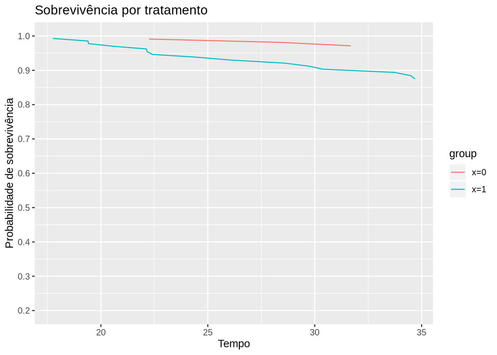

```r
kmsurvival_t <- survfit(Surv(stop, status) ~ x, data = sim.data)
summary_kmsurvival_t <- summary(kmsurvival_t)
data.frame(time = summary_kmsurvival_t$time, group = summary_kmsurvival_t$strata, prob = summary_kmsurvival_t$surv) %>%
  ggplot(aes(x = time, y = prob, col = group)) +
  geom_line() +
  labs(x = 'Tempo', y = 'Probabilidade de sobrevivência', title = paste('Sobrevivência por tratamento')) +
  scale_y_continuous(limits = c(0.2, 1), breaks = seq(.2, 1, .1))
```

As seen on the plot above, the treatment has the opposite effect, since it makes it more likely for the client to leave the company.

```r
weibull_t <- survreg(Surv(stop, status) ~ factor(x), data = sim.data, dist="weibull")
summary(weibull_t)
```

```
##
## Call:
## survreg(formula = Surv(stop, status) ~ factor(x), data = sim.data,
##     dist = "weibull")
##                Value Std. Error    z      p
## (Intercept)  0.36353    0.00252  144 <2e-16
## factor(x)1   0.17490    0.00388   45 <2e-16
## Log(scale)  -1.47787    0.00000 -Inf <2e-16
##
## Scale= 0.228
##
## Weibull distribution
## Loglik(model)= -84228.4   Loglik(intercept only)= -120.1
##  Chisq= -168216.5 on 1 degrees of freedom, p= 1
## Number of Newton-Raphson Iterations: 30
## n= 1000
```